# Comparison of LC and CE

Bryon Drown

January 10, 2022

# Intro

This dataset consists of LC-MS/MS and CE-MS/MS acquisitions of GELFrEE fractions from heart, spleen, and small intestine lysates. For CE-MS/MS acquisition, a CESI-8000 was used to introduce samples to a Thermo Orbitrap Eclipse MS. For LC-MS/MS acquisitions, an Ultimate 3000 nanoLC was used to separate/introduce samples with a handpacked PLRPS column to a Thermo Orbitrap Fusion Lumos Tribrid MS.

Resulting raw files were searched on TDportal 4.0 against a human database with curated histone proteoforms. Isoforms, proteoforms, and hits were dumped using TDviewer and saved as csv files in `tdreport_dumps`. The following analysis utilizes these files as input.

First, we need to calculate the properties of proteins. A python script that utilizes Biopython was written:

```r
python calc_protein_props.py tdreport_dumps/hits_list.csv data/hits_list_props.csv
```

# Overall physiochemical properties

It’s possible that CE and LC will create a bias in the type of proteoforms detected. We’ll first look at the distribution of several physiochemical properties that can be calculated with ProtParam.

```r
# Overall distribution of proteoform physiochemical properties

# pI
plot <- hits %>%
  select(PFR, pI, Separation, Tissue) %>%
  unique() %>%
  ggplot(aes(y = pI, x = Separation, fill = Tissue)) +
    geom_violin() +
    theme_bw(base_size = 16)
plot
pdf(file = "figures/LCvsCE_pI_overall.pdf", width = 7, height = 5,
    pointsize = 16)
```

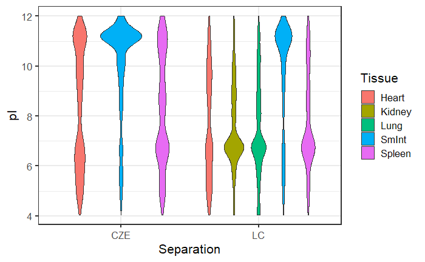

```r
print(plot)
dev.off()
```

```r
# Lipophilicity
plot <- hits %>%
  select(PFR, GRAVY, Separation, Tissue) %>%
  unique() %>%
  ggplot(aes(y = GRAVY, x = Separation, fill = Tissue)) +
    geom_violin() +
    theme_bw(base_size = 16) +
    labs(y = "Lipophilicity (GRAVY)")
plot
pdf(file = "figures/LCvsCE_GRAVY_overall.pdf", width = 7, height = 5,
    pointsize = 16)
```

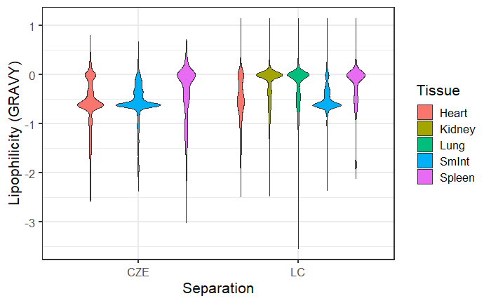

```r
print(plot)
dev.off()
```

```r
# Mass
plot <- hits %>%
  select(PFR, Monoisotopic_Mass, Separation, Tissue) %>%
  unique() %>%
  ggplot(aes(y = Monoisotopic_Mass, x = Separation, fill = Tissue)) +
    geom_violin() +
    theme_bw(base_size = 16) +
    labs(y = "Monoisotopic Mass (Da)")
plot
pdf(file = "figures/LCvsCE_Mass_overall.pdf", width = 7, height = 5,
    pointsize = 16)
```

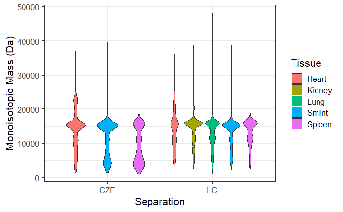

```r
print(plot)
dev.off()
```

# Separation Ability

## Mass vs Retention Time

```r
df <- hits %>%
  filter(Tissue %in% c("Heart", "SmInt", "Spleen")) %>%
  select(PFR, Tissue, Separation, Fraction, Average_Retention_Time, Monoisotopic_Mass) %>%
  unique() %>%
  group_by(PFR, Tissue, Separation, Fraction) %>%
  summarise(Time = mean(Average_Retention_Time), Mass = mean(Monoisotopic_Mass), .groups = "drop")

plot <- df %>%
  ggplot(aes(x = Time, y = Mass/1000, color = Separation)) +
  geom_point() +
  geom_smooth(aes(color = 'black'),method = "lm") +
  facet_grid(Separation ~ Fraction) +
  labs(x = "Time (min)", y = "Mass (kDa)") +
  theme_bw(base_size = 16) +
  theme(legend.position = 'none',
        axis.title = element_text(face = "bold"))
plot
pdf(file = "figures/LCvsCE_TimevsMass.pdf", width = 11, height = 4)
```

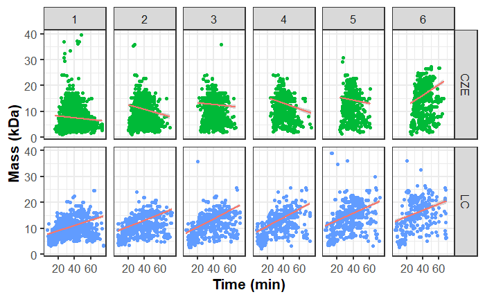

```r
print(plot)
dev.off()
```

```r
df <- mutate(df, SepFraction = paste0(Separation, Fraction))
s <- by(df, df$SepFraction, FUN=function(X) cor(X$Time, X$Mass, method = "spearman"))
p <- by(df, df$SepFraction, FUN=function(X) cor(X$Time, X$Mass, method = "pearson"))
r <- data.frame(group = dimnames(s)[[1]], spearman = as.vector(s), pearson = as.vector(p))

dat <- r %>%
  mutate(Frac = str_sub(group, -1, -1), Sep = str_sub(group, 1, -2)) %>%
  mutate(z = 0.5 * (log(1 + pearson) - log(1 - pearson))) %>%
  select(Frac, Sep, pearson, z)

anova_model <- aov(z ~ Frac + Sep, data=dat)
Anova(anova_model, type = 2)
```

```
Anova Table (Type II tests)

Response: z
           Sum Sq Df F value   Pr(>F)
Frac      0.04090  5  0.1923 0.952716
Sep       0.82899  1 19.4911 0.006925 **
Residuals 0.21266  5
---
Signif. codes:  0 ‘***’ 0.001 ‘**’ 0.01 ‘*’ 0.05 ‘.’ 0.1 ‘ ’ 1
```

## GRAVY vs Time

```r
df <- hits %>%
  filter(Tissue %in% c("Heart", "SmInt", "Spleen")) %>%
  select(PFR, Tissue, Separation, Fraction, Average_Retention_Time, GRAVY) %>%
  unique() %>%
  group_by(PFR, Tissue, Separation, Fraction) %>%
  summarise(Time = mean(Average_Retention_Time), GRAVY = mean(GRAVY), .groups = "drop")

plot <- df %>%
  ggplot(aes(x = Time, y = GRAVY, color = Separation)) +
  geom_point() +
  geom_smooth(aes(color = 'black'),method = "lm") +
  facet_grid(Separation ~ Fraction) +
  labs(x = "Time (min)", y = "Hydrophobicity (GRAVY)") +
  theme_bw(base_size = 16) +
  theme(legend.position = 'none',
        axis.title = element_text(face = "bold"))
plot
```

```
Warning: Removed 1 rows containing non-finite values (stat_smooth).
Warning: Removed 1 rows containing missing values (geom_point).
```

```r
pdf(file = "figures/LCvsCE_TimevsGRAVY.pdf", width = 11, height = 4)
```

```r
print(plot)
```

```
Warning: Removed 1 rows containing non-finite values (stat_smooth).
Warning: Removed 1 rows containing missing values (geom_point).
```

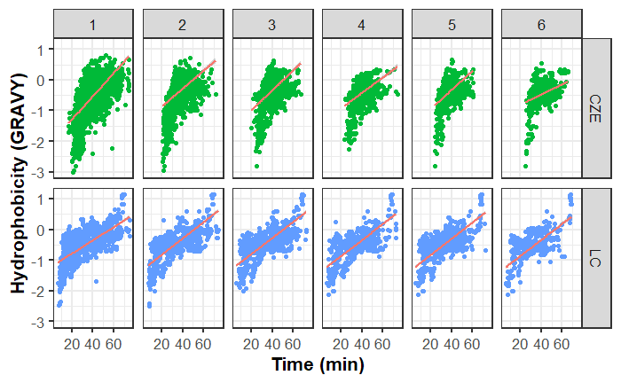

```r
dev.off()
```

```r
df <- mutate(df, SepFraction = paste0(Separation, Fraction))
s <- by(df, df$SepFraction, FUN=function(X) stats::cor(X$Time, X$GRAVY, method = "spearman", use = "complete.obs"))
p <- by(df, df$SepFraction, FUN=function(X) stats::cor(X$Time, X$GRAVY, method = "pearson", use = "complete.obs"))
r <- data.frame(group = dimnames(s)[[1]], spearman = as.vector(s), pearson = as.vector(p))
r
```

| group | spearman | pearson |
| --- | --- | --- |
| CZE1 | 0.6902787 | 0.6275391 |
| CZE2 | 0.4267828 | 0.4542701 |
| CZE3 | 0.5984638 | 0.4985189 |
| CZE4 | 0.6118264 | 0.5004300 |
| CZE5 | 0.6344112 | 0.5105759 |
| CZE6 | 0.4397797 | 0.3975713 |
| LC1 | 0.6660114 | 0.6761259 |
| LC2 | 0.6546799 | 0.7412253 |
| LC3 | 0.6338370 | 0.7205320 |
| LC4 | 0.6005039 | 0.7151419 |

[output cut: 2 more lines]

```r
dat <- r %>%
  mutate(Frac = str_sub(group, -1, -1), Sep = str_sub(group, 1, -2)) %>%
  mutate(z = 0.5 * (log(1 + pearson) - log(1 - pearson))) %>%
  select(Frac, Sep, pearson, z)

anova_model <- aov(z ~ Frac + Sep, data=dat)
Anova(anova_model, type = 2)
```

```
Anova Table (Type II tests)

Response: z
           Sum Sq Df F value  Pr(>F)
Frac      0.01571  5  0.3183 0.88270
Sep       0.34365  1 34.8131 0.00199 **
Residuals 0.04936  5
---
Signif. codes:  0 ‘***’ 0.001 ‘**’ 0.01 ‘*’ 0.05 ‘.’ 0.1 ‘ ’ 1
```

## Time vs Mass/Charge

```r
library(Peptides)

df <- hits %>%
  mutate(ChargeAt24 = charge(Sequence, pH = 2.4, pKscale = "Bjellqvist")) %>%
  mutate(mz = Monoisotopic_Mass / ChargeAt24) %>%
  filter(Tissue %in% c("Heart", "SmInt", "Spleen")) %>%
  select(PFR, Tissue, Separation, Fraction, Average_Retention_Time, mz) %>%
  unique() %>%
  group_by(PFR, Tissue, Separation, Fraction) %>%
  summarise(mz = mean(mz), Time = mean(Average_Retention_Time), .groups = "drop")

plot <- df %>%
  ggplot(aes(x = Time, y = mz, color = Separation)) +
  geom_point() +
  geom_smooth(aes(color = 'black'),method = "lm") +
  facet_grid(Separation ~ Fraction) +
  labs(x = "Time (min)", y = "Mass to Charge Ratio") +
  theme_bw(base_size = 16) +
  theme(legend.position = 'none',
        axis.title = element_text(face = "bold"))
plot
pdf(file = "figures/LCvsCE_TimevsMZ.pdf", width = 11, height = 4)
```

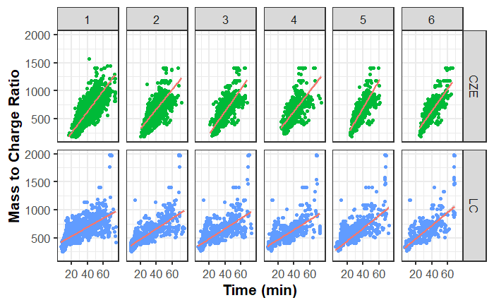

```r
print(plot)
dev.off()
```

```r
df <- mutate(df, SepFraction = paste0(Separation, Fraction))
s <- by(df, df$SepFraction, FUN=function(X) stats::cor(X$Time, X$mz, method = "spearman", use = "complete.obs"))
p <- by(df, df$SepFraction, FUN=function(X) stats::cor(X$Time, X$mz, method = "pearson", use = "complete.obs"))
r <- data.frame(group = dimnames(s)[[1]], spearman = as.vector(s), pearson = as.vector(p))
r
```

| group | spearman | pearson |
| --- | --- | --- |
| CZE1 | 0.8728377 | 0.8258448 |
| CZE2 | 0.6892100 | 0.6965736 |
| CZE3 | 0.7808692 | 0.7684291 |
| CZE4 | 0.7388745 | 0.7074702 |
| CZE5 | 0.7923051 | 0.8078082 |
| CZE6 | 0.8153638 | 0.8291877 |
| LC1 | 0.6635429 | 0.6332742 |
| LC2 | 0.7313807 | 0.6773083 |
| LC3 | 0.6609820 | 0.6235449 |
| LC4 | 0.6521607 | 0.6023278 |

[output cut: 2 more lines]

```r
dat <- r %>%
  mutate(Frac = str_sub(group, -1, -1), Sep = str_sub(group, 1, -2)) %>%
  mutate(z = 0.5 * (log(1 + pearson) - log(1 - pearson))) %>%
  select(Frac, Sep, pearson, z)

anova_model <- aov(z ~ Frac + Sep, data=dat)
Anova(anova_model, type = 2)
```

```
Anova Table (Type II tests)

Response: z
            Sum Sq Df F value   Pr(>F)
Frac      0.055741  5  0.9654 0.514925
Sep       0.246744  1 21.3681 0.005722 **
Residuals 0.057737  5
---
Signif. codes:  0 ‘***’ 0.001 ‘**’ 0.01 ‘*’ 0.05 ‘.’ 0.1 ‘ ’ 1
```

## Relationship between physiochemical properties

```r
df <- hits %>%
  mutate(ChargeAt24 = charge(Sequence, pH = 2.4, pKscale = "Bjellqvist")) %>%
  mutate(mz = Monoisotopic_Mass / ChargeAt24) %>%
  filter(Tissue %in% c("Heart", "SmInt", "Spleen")) %>%
  select(PFR, Tissue, Separation, Fraction, Average_Retention_Time, Monoisotopic_Mass, GRAVY, pI, mz, ChargeAt24) %>%
  unique() %>%
  group_by(PFR, Tissue, Separation, Fraction) %>%
  summarise(mz = mean(mz), Time = mean(Average_Retention_Time), Mass = mean(Monoisotopic_Mass),
            pI = mean(pI), GRAVY = mean(GRAVY), ChargeAt24 = mean(ChargeAt24), .groups = "drop")

plot <- df %>%
  ggplot(aes(x = GRAVY, y = mz/1000, color = Separation)) +
  geom_point() +
  geom_smooth(method = "lm") +
  labs(x = "Hydrophobicity (GRAVY)", y = "Mass to Charge Ratio at pH 2.4") +
  theme_bw(base_size = 16) +
  theme(legend.position = 'right',
        axis.title = element_text(face = "bold"))
plot
```

```
Warning: Removed 1 rows containing non-finite values (stat_smooth).
Warning: Removed 1 rows containing missing values (geom_point).
```

```
Warning: Removed 1 rows containing non-finite values (stat_smooth).
Warning: Removed 1 rows containing missing values (geom_point).
```

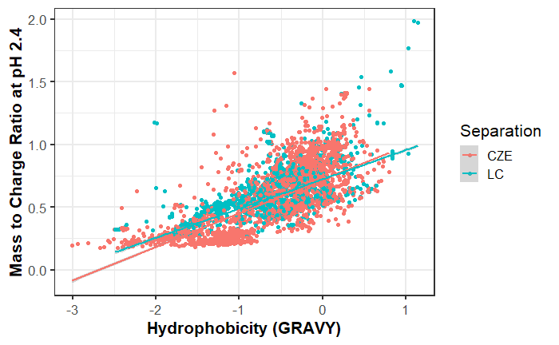

```r
ggsave("figures/GRAVYvsMZ.pdf", plot, width = 7, height = 5, units = "in")
```

```r
plot <- df %>%
  ggplot(aes(y = Mass/1000, x = GRAVY, color = Separation)) +
  geom_point() +
  geom_smooth(method = "lm") +
  labs(x =  "Hydrophobicity (GRAVY)", y = "Mass (kDa)") +
  theme_bw(base_size = 16) +
  theme(legend.position = 'right',
        axis.title = element_text(face = "bold"))
plot
```

```
Warning: Removed 1 rows containing non-finite values (stat_smooth).
Warning: Removed 1 rows containing missing values (geom_point).
```

```
Warning: Removed 1 rows containing non-finite values (stat_smooth).
Warning: Removed 1 rows containing missing values (geom_point).
```

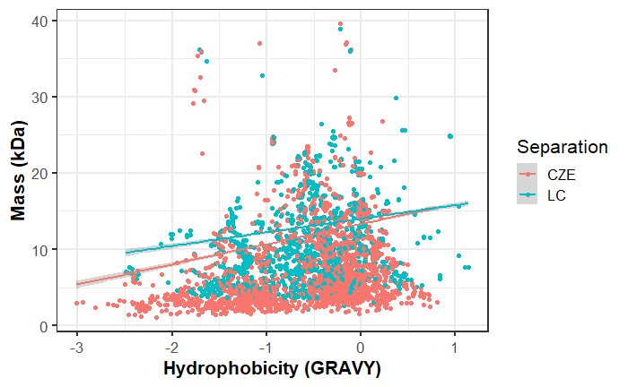

```r
ggsave("figures/GRAVYvsMass.pdf", plot, width = 7, height = 5, units = "in")
```

```r
plot <- df %>%
  ggplot(aes(y = ChargeAt24, x = GRAVY, color = Separation)) +
  geom_point() +
  geom_smooth(method = "lm") +
  labs(x =  "Hydrophobicity (GRAVY)", y = "Charge at pH 2.4") +
  theme_bw(base_size = 16) +
  theme(legend.position = 'right',
        axis.title = element_text(face = "bold"))
plot
```

```
Warning: Removed 1 rows containing non-finite values (stat_smooth).
Warning: Removed 1 rows containing missing values (geom_point).
```

```
Warning: Removed 1 rows containing non-finite values (stat_smooth).
Warning: Removed 1 rows containing missing values (geom_point).
```

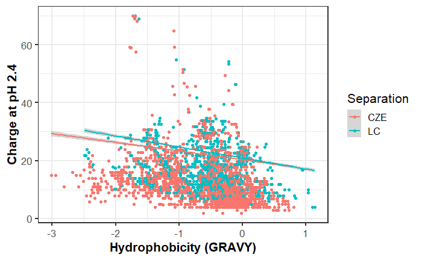

```r
ggsave("figures/GRAVYvsCharge.pdf", plot, width = 7, height = 5, units = "in")
```

# Proteome coverage

Proteome coverage is a metric first described by James Fulcher at PNNL: Fulcher, J. M.; Makaju, A.; Moore, R. J.; Zhou, M.; Bennett, D. A.; Jager, P. L. D.; Qian, W.-J.; Paša-Tolić, L.; Petyuk, V. A. Enhancing Top-Down Proteomics of Brain Tissue with FAIMS. J Proteome Res 2021, 20 (5), 2780–2795. https://doi.org/10.1021/acs.jproteome.1c00049.

The idea is to count the length of non-redundant sequences covered by proteoforms. The merging of proteoform sequences is performed by helper functions in `proteome_coverage.R`

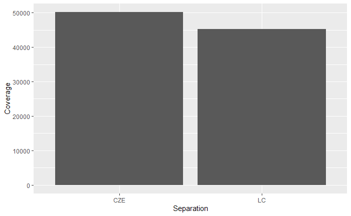

```r
source("proteome_coverage.R")

get_coverage <- function(df) {
  df <- df %>% select(Accession, Start_Index, End_Index) %>%
    unique()
  y <- lapply(split(df[2:3], df$Accession), proteome_coverage)
  return(sum(unlist(y)))
}

df <- hits %>%
  filter(Tissue %in% c("Heart", "SmInt", "Spleen")) %>%
  select(Separation, Accession, Start_Index, End_Index)
x <- lapply(split(df[2:4], df$Separation), get_coverage)
x <- as.data.frame(x) %>%
  pivot_longer(cols = c("CZE", "LC"), names_to = "Separation", values_to = "Coverage") %>%
  mutate(Percent_Coverage = Coverage/human_proteome_aa)

ggplot(x, aes(x = Separation, y = Coverage)) +
  geom_col()
```

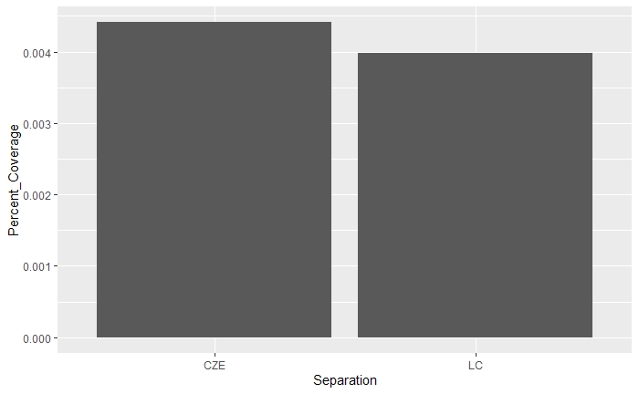

```r
ggplot(x, aes(x = Separation, y = Percent_Coverage)) +
  geom_col()
```

# Unique proteoforms/proteins

## Venn Diagrams

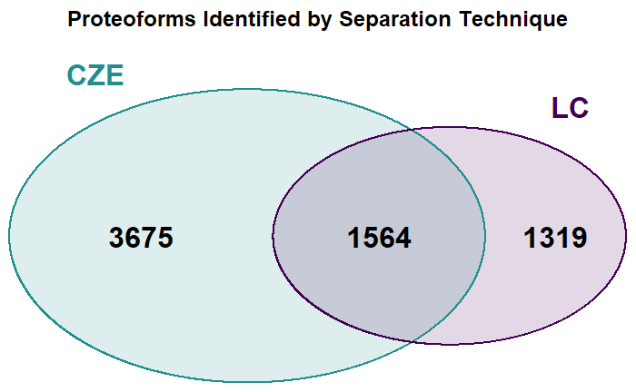

```r
venn.pfr <- hits %>%
  filter(Tissue %in% c("Heart", "SmInt", "Spleen")) %>%
  select(PFR, Separation) %>%
  unique() %>%
  arrange(PFR)

lc <- filter(venn.pfr, Separation == "LC")$PFR
cze <- filter(venn.pfr, Separation == "CZE")$PFR

# Output for external analysis
write(lc, "output_data/pfr_lc.txt", ncolumns = 1)
write(cze, "output_data/pfr_cze.txt", ncolumns = 1)

plt <- venn.diagram(
  x = list(lc, cze),
  category.names = c("LC", "CZE"),
  filename = NULL,

  # Title
  main = "Proteoforms Identified by Separation Technique",
  main.cex = 1.5,
  main.fontface = "bold",
  main.fontfamily = "sans",

  # Colors
  col=c("#440154ff", '#21908dff'),
  fill = c(alpha("#440154ff",0.3), alpha('#21908dff',0.3)),
  cat.col=c("#440154ff", '#21908dff'),

  # Numbers
  cex = 2,
  fontface = "bold",
  fontfamily = "sans",
  cat.pos = c(-150, 150),
  cat.dist = c(0.055, 0.055),

  # Set names
  cat.cex = 2,
  cat.fontface = "bold",
  cat.default.pos = "outer",
  cat.fontfamily = "sans"
)
grid::grid.newpage()
grid::grid.draw(plt)
```

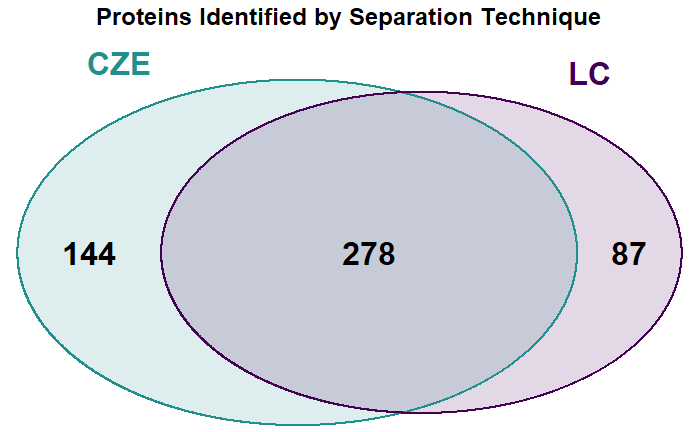

```r
venn.protein <- hits %>%
  filter(Tissue %in% c("Heart", "SmInt", "Spleen")) %>%
  select(Uniprot_Id, Separation) %>%
  unique() %>%
  arrange(Uniprot_Id)

lc <- filter(venn.protein, Separation == "LC")$Uniprot_Id
cze <- filter(venn.protein, Separation == "CZE")$Uniprot_Id

# Output for external analysis
write(lc, "output_data/protein_lc.txt", ncolumns = 1)
write(cze, "output_data/protein_cze.txt", ncolumns = 1)

plt <- venn.diagram(
  x = list(lc, cze),
  category.names = c("LC", "CZE"),
  filename = NULL,

  # Title
  main = "Proteins Identified by Separation Technique",
  main.cex = 1.5,
  main.fontface = "bold",
  main.fontfamily = "sans",

  # Colors
  col=c("#440154ff", '#21908dff'),
  fill = c(alpha("#440154ff",0.3), alpha('#21908dff',0.3)),
  cat.col=c("#440154ff", '#21908dff'),

  # Numbers
  cex = 2,
  fontface = "bold",
  fontfamily = "sans",
  cat.pos = c(-150, 150),
  cat.dist = c(0.055, 0.055),

  # Set names
  cat.cex = 2,
  cat.fontface = "bold",
  cat.default.pos = "outer",
  cat.fontfamily = "sans"
)
grid::grid.newpage()
grid::grid.draw(plt)
```

## Proteoforms per Protein

It looks like CZE is revealing more proteoforms per protein entry. I’m interested to see if this phenomenon is evenly distributed or if there is a subset of proteins (e.g. histones) that are driving this observation.

```r
# First count the number of proteoforms
pfr_count <- hits %>%
  filter(Tissue %in% c("Heart", "SmInt", "Spleen")) %>%
  select(PFR, Uniprot_Id, Separation) %>%
  unique() %>%
  group_by(Uniprot_Id, Separation) %>%
  summarise(Count = n(), .groups = "drop")

# Which protein entries have the most proteoforms?
pfr_count %>%
  arrange(-Count) %>%
  pivot_wider(names_from = "Separation", values_from = "Count")
```

| Uniprot_Id | CZE | LC |
| --- | --- | --- |
| HBB_HUMAN | 556 | 394 |
| H33_HUMAN | 527 | 292 |
| H31_HUMAN | 352 | 223 |
| H32_HUMAN | 255 | 136 |
| ACTB_HUMAN | 153 | 36 |
| HBA_HUMAN | 144 | 74 |
| HSPB1_HUMAN | 131 | 15 |
| H4_HUMAN | 127 | 74 |
| MLRV_HUMAN | 102 | 116 |
| H14_HUMAN | 115 | 9 |

[output cut: 499 more lines]

There are no big surprises for which proteins are more frequently characterized

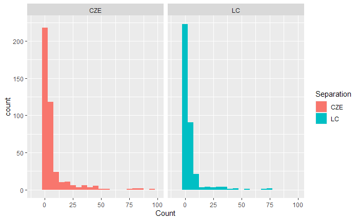

```r
ggplot(pfr_count, aes(x = Count, fill = Separation)) +
  geom_histogram(binwidth = 5) +
  facet_wrap(~ Separation) +
  xlim(c(-10,100))
```

## Properties of unique proteoforms

The difference in physiochemical properties may be more apparent when looking only at unqiue proteoforms. Here proteoforms that were observed by both separation methods are removed.

### pI

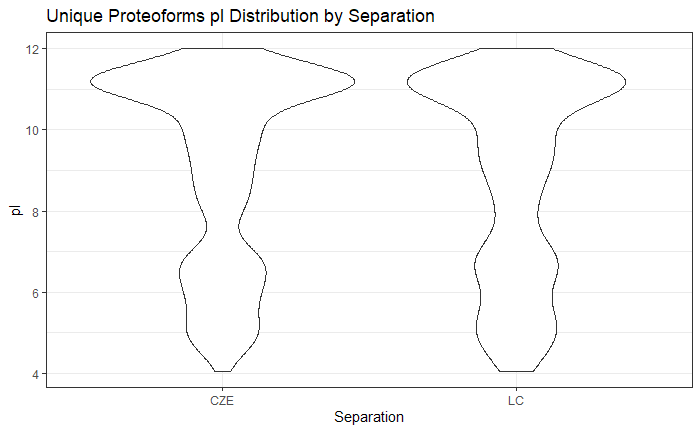

```r
# Vectors of all PFRs found by each method
lc <- filter(venn.pfr, Separation == "LC")$PFR
cze <- filter(venn.pfr, Separation == "CZE")$PFR

# Vectors of unique PFRs found by each method
lc.unique <- setdiff(lc, cze)
cze.unique <- setdiff(cze, lc)
both <- intersect(lc, cze)

lc <- hits %>%
  filter(PFR %in% lc.unique) %>%
  select(PFR, pI, GRAVY, Monoisotopic_Mass, Separation, Tissue) %>%
  unique()
cze <- hits %>%
  filter(PFR %in% cze.unique) %>%
  select(PFR, pI, GRAVY, Monoisotopic_Mass, Separation, Tissue) %>%
  unique()

# Grab the properties of the PFRs from hits
hits %>%
  filter(Tissue %in% c("Heart", "SmInt", "Spleen")) %>%
  filter(!PFR %in% both) %>%
  select(PFR, pI, Separation) %>%
  unique() %>%
  ggplot(aes(y = pI, x = Separation)) +
    geom_violin() +
    theme_bw() +
    labs(title = "Unique Proteoforms pI Distribution by Separation")
```

```r
plot <- hits %>%
  filter(Tissue %in% c("Heart", "SmInt", "Spleen")) %>%
  filter(!PFR %in% both) %>%
  select(PFR, pI, Separation, Tissue) %>%
  unique() %>%
  ggplot(aes(y = pI, x = Separation, fill = Tissue)) +
    geom_violin() +
    theme_bw(base_size = 16) +
    labs(y = "pI")
plot
pdf(file = "figures/LCvsCE_pI_Unique.pdf", width = 7, height = 5,
    pointsize = 16)
```

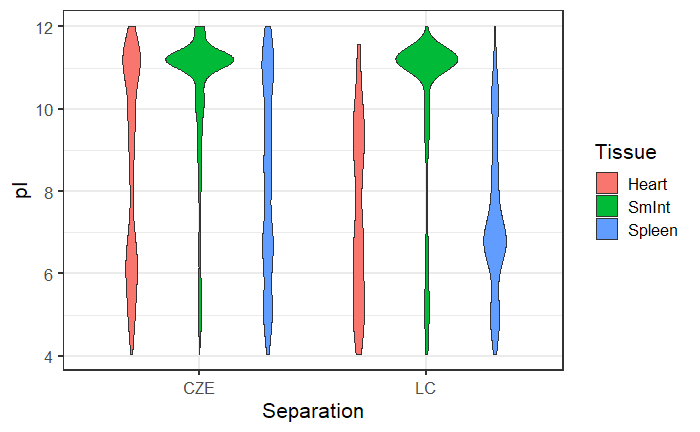

```r
print(plot)
dev.off()
```

```r
# Kolmogorov–Smirnov test to compare distributions
ks.test(lc$pI, cze$pI)
```

```
    Two-sample Kolmogorov-Smirnov test

data:  lc$pI and cze$pI
D = 0.12162, p-value < 2.2e-16
alternative hypothesis: two-sided
```

Basic proteins seem to be enriched in CZE measurements but it’s no more apparent than when looking at overall proteoforms.

### Lipophilicity

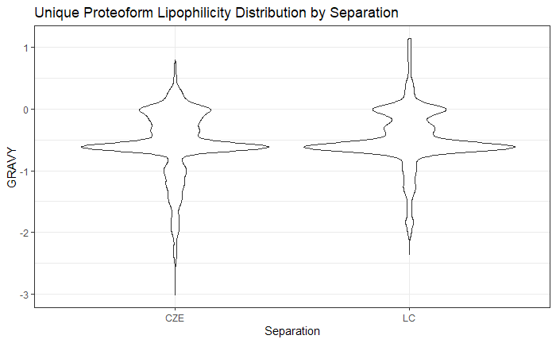

```r
# Lipophilicity
hits %>%
  filter(Tissue %in% c("Heart", "SmInt", "Spleen")) %>%
  filter(!PFR %in% both) %>%
  select(PFR, GRAVY, Separation, Tissue) %>%
  unique() %>%
  ggplot(aes(y = GRAVY, x = Separation)) +
    geom_violin() +
    theme_bw() +
    labs(title = "Unique Proteoform Lipophilicity Distribution by Separation")
```

```r
plot <- hits %>%
  filter(Tissue %in% c("Heart", "SmInt", "Spleen")) %>%
  filter(!PFR %in% both) %>%
  select(PFR, GRAVY, Separation, Tissue) %>%
  unique() %>%
  ggplot(aes(y = GRAVY, x = Separation, fill = Tissue)) +
    geom_violin() +
    theme_bw(base_size = 16) +
    labs(y = "Lipophilicity (GRAVY)")
plot
pdf(file = "figures/LCvsCE_GRAVY_Unique.pdf", width = 7, height = 5,
    pointsize = 16)
```

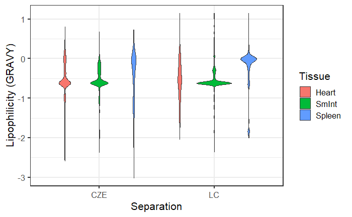

```r
print(plot)
dev.off()
```

```r
# Kolmogorov–Smirnov test to compare distributions
ks.test(lc$GRAVY, cze$GRAVY)
```

```
    Two-sample Kolmogorov-Smirnov test

data:  lc$GRAVY and cze$GRAVY
D = 0.07049, p-value = 4.342e-06
alternative hypothesis: two-sided
```

### Mass

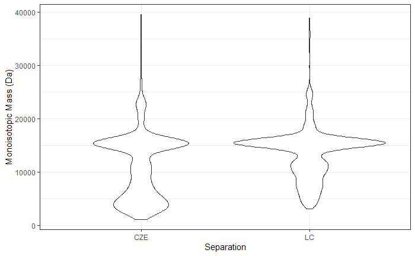

```r
# Mass
hits %>%
  filter(Tissue %in% c("Heart", "SmInt", "Spleen")) %>%
  filter(!PFR %in% both) %>%
  select(PFR, Monoisotopic_Mass, Separation, Tissue) %>%
  unique() %>%
  ggplot(aes(y = Monoisotopic_Mass, x = Separation)) +
    geom_violin() +
    theme_bw() +
    labs(y = "Monoisotopic Mass (Da)")
```

```r
plot <- hits %>%
  filter(Tissue %in% c("Heart", "SmInt", "Spleen")) %>%
  filter(!PFR %in% both) %>%
  select(PFR, Monoisotopic_Mass, Separation, Tissue) %>%
  unique() %>%
  ggplot(aes(y = Monoisotopic_Mass, x = Separation, fill = Tissue)) +
    geom_violin() +
    theme_bw(base_size = 16) +
    labs(y = "Monoisotopic Mass (Da)")
plot
pdf(file = "figures/LCvsCE_Mass_Unique.pdf", width = 7, height = 5,
    pointsize = 16)
```

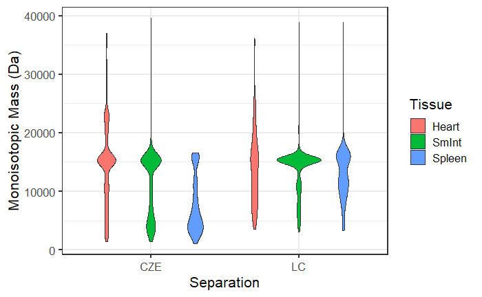

```r
print(plot)
dev.off()
```

```r
# Kolmogorov–Smirnov test to compare distributions
ks.test(lc$Monoisotopic_Mass, cze$Monoisotopic_Mass)
```

```
    Two-sample Kolmogorov-Smirnov test

data:  lc$Monoisotopic_Mass and cze$Monoisotopic_Mass
D = 0.24024, p-value < 2.2e-16
alternative hypothesis: two-sided
```

## Properties of unique proteins

### pI

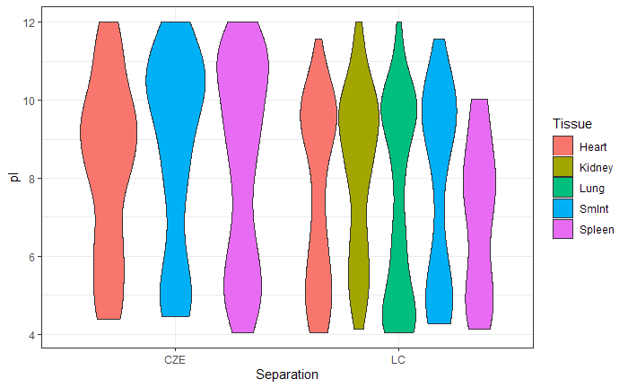

```r
# Vectors of all PFRs found by each method
lc <- filter(venn.protein, Separation == "LC")$Uniprot_Id
cze <- filter(venn.protein, Separation == "CZE")$Uniprot_Id

# Vectors of unique PFRs found by each method
lc.unique <- setdiff(lc, cze)
cze.unique <- setdiff(cze, lc)
both <- intersect(lc, cze)

# Dataframes of properties for when performing K-S tests
lc <- hits %>%
  filter(Tissue %in% c("Heart", "SmInt", "Spleen")) %>%
  filter(Uniprot_Id %in% lc.unique) %>%
  select(PFR, pI, GRAVY, Monoisotopic_Mass, Separation, Tissue) %>%
  unique()
cze <- hits %>%
  filter(Tissue %in% c("Heart", "SmInt", "Spleen")) %>%
  filter(Uniprot_Id %in% cze.unique) %>%
  select(PFR, pI, GRAVY, Monoisotopic_Mass, Separation, Tissue) %>%
  unique()

# Grab the properties of the PFRs from hits
hits %>%
  filter(!Uniprot_Id %in% both) %>%
  select(PFR, pI, Separation, Tissue) %>%
  unique() %>%
  ggplot(aes(y = pI, x = Separation, fill = Tissue)) +
    geom_violin() +
    theme_bw() +
    labs(y = "pI")
```

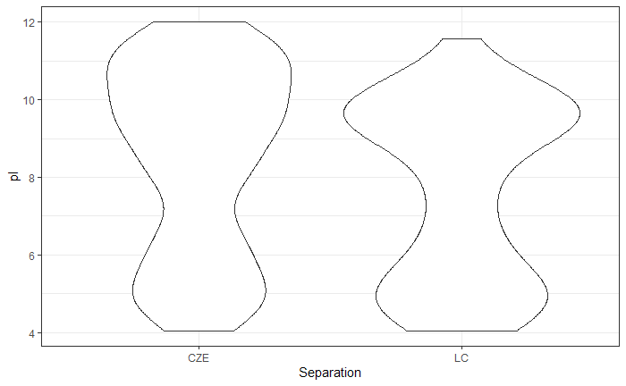

```r
hits %>%
  filter(Tissue %in% c("Heart", "SmInt", "Spleen")) %>%
  filter(!Uniprot_Id %in% both) %>%
  select(PFR, pI, Separation) %>%
  unique() %>%
  ggplot(aes(y = pI, x = Separation)) +
    geom_violin() +
    theme_bw() +
    labs(y = "pI")
```

```r
# Kolmogorov–Smirnov test to compare distributions
ks.test(lc$pI, cze$pI)
```

```
    Two-sample Kolmogorov-Smirnov test

data:  lc$pI and cze$pI
D = 0.23974, p-value = 2.003e-06
alternative hypothesis: two-sided
```

### Lipophilicity

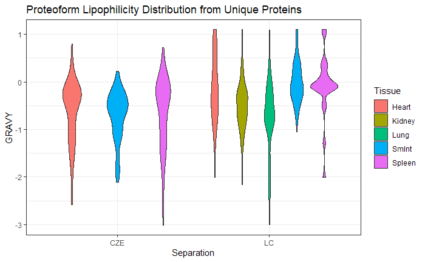

```r
# Lipophilicity
hits %>%
  filter(!Uniprot_Id %in% both) %>%
  select(PFR, GRAVY, Separation, Tissue) %>%
  unique() %>%
  ggplot(aes(y = GRAVY, x = Separation, fill = Tissue)) +
    geom_violin() +
    theme_bw() +
    labs(title = "Proteoform Lipophilicity Distribution from Unique Proteins")
```

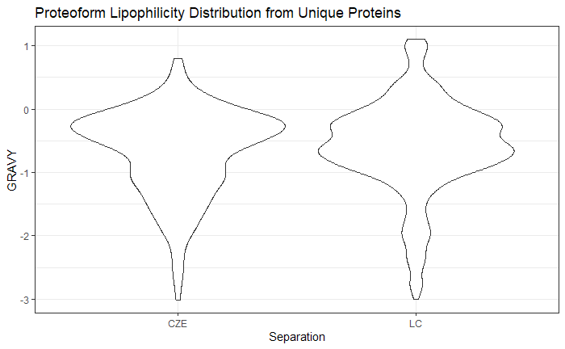

```r
hits %>%
  filter(!Uniprot_Id %in% both) %>%
  select(PFR, GRAVY, Separation, Tissue) %>%
  unique() %>%
  ggplot(aes(y = GRAVY, x = Separation)) +
    geom_violin() +
    theme_bw() +
    labs(title = "Proteoform Lipophilicity Distribution from Unique Proteins")
```

```r
# Kolmogorov–Smirnov test to compare distributions
ks.test(lc$GRAVY, cze$GRAVY)
```

```
    Two-sample Kolmogorov-Smirnov test

data:  lc$GRAVY and cze$GRAVY
D = 0.36227, p-value = 4.008e-14
alternative hypothesis: two-sided
```

### Mass

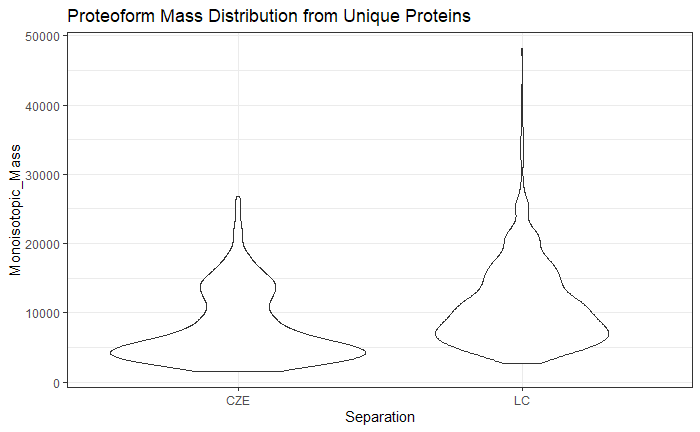

```r
# Mass
hits %>%
  filter(!Uniprot_Id %in% both) %>%
  select(PFR, Monoisotopic_Mass, Separation, Tissue) %>%
  unique() %>%
  ggplot(aes(y = Monoisotopic_Mass, x = Separation)) +
    geom_violin() +
    theme_bw() +
    labs(title = "Proteoform Mass Distribution from Unique Proteins")
```

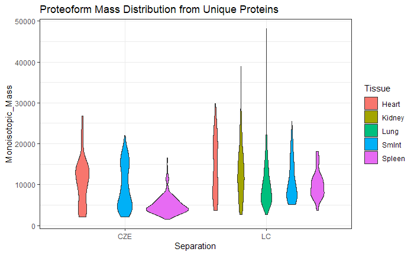

```r
hits %>%
  filter(!Uniprot_Id %in% both) %>%
  select(PFR, Monoisotopic_Mass, Separation, Tissue) %>%
  unique() %>%
  ggplot(aes(y = Monoisotopic_Mass, x = Separation, fill = Tissue)) +
    geom_violin() +
    theme_bw() +
    labs(title = "Proteoform Mass Distribution from Unique Proteins")
```

```r
# Kolmogorov–Smirnov test to compare distributions
ks.test(lc$Monoisotopic_Mass, cze$Monoisotopic_Mass)
```

```
    Two-sample Kolmogorov-Smirnov test

data:  lc$Monoisotopic_Mass and cze$Monoisotopic_Mass
D = 0.44319, p-value < 2.2e-16
alternative hypothesis: two-sided
```

# PTM Enrichment

## PFR level

Do the two separation techniques favor proteoforms with particular PTMs? The goal here is to see if particular PTMs are enriched in each dataset. I’m going to ignore N- and C-terminal modifications and just pull whatever is in the `Modification_Codes` column of the Hit Report.

```r
# Many of the PTMs that are actually very specific (e.g. phosphoserine)
# We instead want to group all phosphorylations together
# ptm_map relates specific PTMs to their more general PSI-MOD entries
ptm_map <- read.csv(file = "data/ptm_mapping.csv")
colnames(ptm_map)[1] <- "Modification_Codes"

df <- hits %>%
  filter(Tissue %in% c("Heart", "SmInt", "Spleen")) %>%
  select(PFR, Separation, Modification_Codes) %>%
  unique() %>%
  separate_rows(Modification_Codes, sep="\\|") %>%
  mutate(Modification_Codes = str_split(Modification_Codes, pattern="@", simplify = TRUE)[,1])

# Now count the number of each PTM in PFRs
# If a PFR contains the same PTM multiple times, it is counted multiple times
ptm_counts <- merge(df, ptm_map)%>%
  select(General.Description, Separation) %>%
  ungroup() %>%
  group_by(General.Description, Separation) %>%
  summarise(Count = n(), .groups = "drop") %>%
  arrange(-Count)

# The Chi-squared test is not accurate when there are fewer than 5 observations
# so I'll remove any PTMs that were seen fewer than 5 times.
ptm_counts <- ptm_counts %>%
  pivot_wider(names_from = Separation, values_from = Count, values_fill = 0) %>%
  filter(CZE >=5 & LC >=5)

# The base Chi-squared test function accepts a matrix with named rows as input
mtx <- ptm_counts %>%
  select(-General.Description) %>%
  as.matrix
rownames(mtx) <- ptm_counts$General.Description

# Let's calculate the rate of observing each mod
ptm_counts <- ptm_counts %>%
  mutate(CZE_rate = CZE / sum(ptm_counts$CZE)) %>%
  mutate(LC_rate = LC / sum(ptm_counts$LC))

# Chi-squared
test <- chisq.test(mtx)
test
```

```
    Pearson's Chi-squared test

data:  mtx
X-squared = 196.35, df = 11, p-value < 2.2e-16
```

```r
# Compare the expected distribution to the actual distribution
ptm_counts$CZE_expected <- test$expected[,"CZE"]
ptm_counts$LC_expected <- test$expected[,"LC"]
ptm_counts
```

| General.Description | CZE | LC | CZE_rate | LC_rate | CZE_expected | LC_expected |
| --- | --- | --- | --- | --- | --- | --- |
| monoacetylated residue | 2723 | 1984 | 0.259828244 | 0.3123425693 | 2930.68916 | 1776.310837 |
| None | 2298 | 1123 | 0.219274809 | 0.1767947103 | 2129.99525 | 1291.004753 |
| phosphorylated residue | 1644 | 1006 | 0.156870229 | 0.1583753149 | 1649.95247 | 1000.047529 |
| monomethylated residue | 1201 | 556 | 0.114599237 | 0.0875314861 | 1093.94962 | 663.050380 |
| trimethylated protonated-residue | 920 | 667 | 0.087786260 | 0.1050062972 | 988.10361 | 598.896388 |
| dimethylated residue | 919 | 642 | 0.087690840 | 0.1010705290 | 971.91540 | 589.084601 |
| half cystine | 360 | 118 | 0.034351145 | 0.0185768262 | 297.61407 | 180.385932 |
| nitrosylated residue | 239 | 165 | 0.022805344 | 0.0259760705 | 251.53992 | 152.460076 |
| monohydroxylated residue | 72 | 5 | 0.006870229 | 0.0007871537 | 47.94202 | 29.057985 |
| pyruvic acid iminylated residue | 48 | 41 | 0.004580153 | 0.0064546599 | 55.41350 | 33.586502 |

[output cut: 2 more lines]

So there is a difference in the distributions by the Chi-squared test. The next step is to figure out which PTMs show significant differences. This will be accomplished by performing each 2x2 Chi-squared test for each PTM vs the sum of all other PTMs. A similar analysis was performed for the observation of birds in different environments:

LATTA, S. C.; HOWELL, C. A.; DETTLING, M. D.; CORMIER, R. L. Use of Data on Avian Demographics and Site Persistence during Overwintering to Assess Quality of Restored Riparian Habitat. Conserv Biol 2012, 26 (3), 482–492. https://doi.org/10.1111/j.1523-1739.2012.01828.x.

```r
# Helper function that will perform the 2x2 Chi-squared and return a p-value
# i: index of row to compare
# m: matrix
compare_ptm <- function(i, m){
  current <- m[i,]
  other <- colSums(m[-i,])
  x <- matrix(c(current, other), 2, 2)
  test = chisq.test(x)
  return(list("p_value" = test$p.value, "chi" = test$statistic))
}

# Iterate over the matrix and calculate the p-value from the Chi-squared test
# comparing the given PTM to all other PTMs
ptm_counts$p_value <- NA
ptm_counts$chi <- NA
for(i in seq(1,nrow(mtx))){
  values <- compare_ptm(i, mtx)
  ptm_counts$p_value[i] <- values$p_value
  ptm_counts$chi[i] <- values$chi
}

# Since there are multiple tests, let's correct the critical p-value
alpha <- 0.01
ptm_counts$p_value <- ptm_counts$p_value * nrow(mtx)

# Which PTMs are significantly different from the expected distribution?
(ptm_counts <- mutate(ptm_counts, significant = p_value < alpha))
```

| General.Description | CZE | LC | CZE_rate | LC_rate | CZE_expected | LC_expected | p_value | chi | significant |
| --- | --- | --- | --- | --- | --- | --- | --- | --- | --- |
| monoacetylated residue | 2723 | 1984 | 0.259828244 | 0.3123425693 | 2930.68916 | 1776.310837 | 2.554820e-12 | 53.88197720 | TRUE |
| None | 2298 | 1123 | 0.219274809 | 0.1767947103 | 2129.99525 | 1291.004753 | 4.341731e-10 | 43.81021933 | TRUE |
| phosphorylated residue | 1644 | 1006 | 0.156870229 | 0.1583753149 | 1649.95247 | 1000.047529 | 9.742101e+00 | 0.05666813 | FALSE |
| monomethylated residue | 1201 | 556 | 0.114599237 | 0.0875314861 | 1093.94962 | 663.050380 | 3.603732e-07 | 30.70551040 | TRUE |
| trimethylated protonated-residue | 920 | 667 | 0.087786260 | 0.1050062972 | 988.10361 | 598.896388 | 2.813946e-03 | 13.53227588 | TRUE |
| dimethylated residue | 919 | 642 | 0.087690840 | 0.1010705290 | 971.91540 | 589.084601 | 4.873433e-02 | 8.25624955 | FALSE |
| half cystine | 360 | 118 | 0.034351145 | 0.0185768262 | 297.61407 | 180.385932 | 3.764614e-08 | 35.09678787 | TRUE |
| nitrosylated residue | 239 | 165 | 0.022805344 | 0.0259760705 | 251.53992 | 152.460076 | 2.531830e+00 | 1.56464863 | FALSE |
| monohydroxylated residue | 72 | 5 | 0.006870229 | 0.0007871537 | 47.94202 | 29.057985 | 3.404239e-07 | 30.81601750 | TRUE |
| pyruvic acid iminylated residue | 48 | 41 | 0.004580153 | 0.0064546599 | 55.41350 | 33.586502 | 1.554712e+00 | 2.29777662 | FALSE |

[output cut: 2 more lines]

```r
data.table::fwrite(ptm_counts, file="output_data/ptm_counts.txt")
```

After the multiple tests, it appears monoacetylation was overrepresented in LC data while monomethylation and half cystine was over-represented in CZE data.

## PfSM level

```r
# Many of the PTMs that are actually very specific (e.g. phosphoserine)
# We instead want to group all phosphorylations together
# ptm_map relates specific PTMs to their more general PSI-MOD entries
ptm_map <- read.csv(file = "data/ptm_mapping.csv")
colnames(ptm_map)[1] <- "Modification_Codes"

df <- hits %>%
  filter(Tissue %in% c("Heart", "SmInt", "Spleen")) %>%
  select(HitId, PFR, Separation, Modification_Codes) %>%
  unique() %>%
  separate_rows(Modification_Codes, sep="\\|") %>%
  mutate(Modification_Codes = str_split(Modification_Codes, pattern="@", simplify = TRUE)[,1])

# Now count the number of each PTM in PFRs
# If a PFR contains the same PTM multiple times, it is counted multiple times
ptm_counts <- merge(df, ptm_map)%>%
  select(General.Description, Separation) %>%
  ungroup() %>%
  group_by(General.Description, Separation) %>%
  summarise(Count = n(), .groups = "drop") %>%
  arrange(-Count)

# The Chi-squared test is not accurate when there are fewer than 5 observations
# so I'll remove any PTMs that were seen fewer than 5 times.
ptm_counts <- ptm_counts %>%
  pivot_wider(names_from = Separation, values_from = Count, values_fill = 0) %>%
  filter(CZE >=5 & LC >=5)

# The base Chi-squared test function accepts a matrix with named rows as input
mtx <- ptm_counts %>%
  select(-General.Description) %>%
  as.matrix
rownames(mtx) <- ptm_counts$General.Description

# Let's calculate the rate of observing each mod
ptm_counts <- ptm_counts %>%
  mutate(CZE_rate = CZE / sum(ptm_counts$CZE)) %>%
  mutate(LC_rate = LC / sum(ptm_counts$LC))

# Chi-squared
test <- chisq.test(mtx)
test
```

```
    Pearson's Chi-squared test

data:  mtx
X-squared = 1790.7, df = 14, p-value < 2.2e-16
```

```r
# Compare the expected distribution to the actual distribution
ptm_counts$CZE_expected <- test$expected[,"CZE"]
ptm_counts$LC_expected <- test$expected[,"LC"]
ptm_counts
```

| General.Description | CZE | LC | CZE_rate | LC_rate | CZE_expected | LC_expected |
| --- | --- | --- | --- | --- | --- | --- |
| None | 61294 | 33518 | 0.5628879991 | 5.460114e-01 | 60631.48306 | 34180.51694 |
| monoacetylated residue | 14628 | 8937 | 0.1343349374 | 1.455846e-01 | 15069.62092 | 8495.37908 |
| phosphorylated residue | 8943 | 6039 | 0.0821272453 | 9.837588e-02 | 9580.86402 | 5401.13598 |
| trimethylated protonated-residue | 7141 | 4793 | 0.0655787386 | 7.807842e-02 | 7631.69344 | 4302.30656 |
| monomethylated residue | 5422 | 1837 | 0.0497924549 | 2.992490e-02 | 4642.06994 | 2616.93006 |
| dimethylated residue | 4948 | 1995 | 0.0454395181 | 3.249874e-02 | 4439.99058 | 2503.00942 |
| half cystine | 2822 | 1033 | 0.0259155861 | 1.682767e-02 | 2465.24034 | 1389.75966 |
| nitrosylated residue | 2081 | 1980 | 0.0191106785 | 3.225439e-02 | 2596.97562 | 1464.02438 |
| deamidated L-asparagine | 804 | 931 | 0.0073834625 | 1.516608e-02 | 1109.51803 | 625.48197 |
| monohydroxylated residue | 344 | 5 | 0.0031590934 | 8.145047e-05 | 223.18259 | 125.81741 |

[output cut: 5 more lines]

```r
# Iterate over the matrix and calculate the p-value from the Chi-squared test
# comparing the given PTM to all other PTMs
ptm_counts$p_value <- NA
ptm_counts$chi <- NA
for(i in seq(1,nrow(mtx))){
  values <- compare_ptm(i, mtx)
  ptm_counts$p_value[i] <- values$p_value
  ptm_counts$chi[i] <- values$chi
}

# Since there are multiple tests, let's correct the critical p-value
alpha <- 0.05
ptm_counts$p_value <- ptm_counts$p_value * nrow(mtx)

# Which PTMs are significantly different from the expected distribution?
(ptm_counts <- mutate(ptm_counts, significant = p_value < alpha))
```

| General.Description | CZE | LC | CZE_rate | LC_rate | CZE_expected | LC_expected | p_value | chi | significant |
| --- | --- | --- | --- | --- | --- | --- | --- | --- | --- |
| None | 61294 | 33518 | 0.5628879991 | 5.460114e-01 | 60631.48306 | 34180.51694 | 2.613776e-10 | 45.240636 | TRUE |
| monoacetylated residue | 14628 | 8937 | 0.1343349374 | 1.455846e-01 | 15069.62092 | 8495.37908 | 1.705278e-09 | 41.570686 | TRUE |
| phosphorylated residue | 8943 | 6039 | 0.0821272453 | 9.837588e-02 | 9580.86402 | 5401.13598 | 1.038281e-28 | 128.959432 | TRUE |
| trimethylated protonated-residue | 7141 | 4793 | 0.0655787386 | 7.807842e-02 | 7631.69344 | 4302.30656 | 4.929457e-21 | 93.919441 | TRUE |
| monomethylated residue | 5422 | 1837 | 0.0497924549 | 2.992490e-02 | 4642.06994 | 2616.93006 | 2.813097e-83 | 379.181815 | TRUE |
| dimethylated residue | 4948 | 1995 | 0.0454395181 | 3.249874e-02 | 4439.99058 | 2503.00942 | 3.436107e-37 | 167.752895 | TRUE |
| half cystine | 2822 | 1033 | 0.0259155861 | 1.682767e-02 | 2465.24034 | 1389.75966 | 1.834960e-32 | 146.118043 | TRUE |
| nitrosylated residue | 2081 | 1980 | 0.0191106785 | 3.225439e-02 | 2596.97562 | 1464.02438 | 5.125747e-64 | 290.747581 | TRUE |
| deamidated L-asparagine | 804 | 931 | 0.0073834625 | 1.516608e-02 | 1109.51803 | 625.48197 | 7.299241e-52 | 234.989862 | TRUE |
| monohydroxylated residue | 344 | 5 | 0.0031590934 | 8.145047e-05 | 223.18259 | 125.81741 | 6.282426e-40 | 180.290301 | TRUE |

[output cut: 5 more lines]

```r
data.table::fwrite(ptm_counts, file="output_data/ptm_counts_psm.txt")
```